# DA 605 - Assignment 12

Dan Fanelli

## BIAS VARIANCE TRADEOFF IN R

- Use the stats and boot libraries
- perform a cross-validation experiment to observe the bias variance tradeoff.
- You’ll use the auto data set from previous assignments.
- This dataset has 392 observations across 5 variables.
- We want to:
  - fit a polynomial model of various degrees using the glm function in R
  - measure the cross validation error using cv.glm function.

```r
library(boot)
library(stats)
library(knitr)

mpg_df <- read.table("auto-mpg.data", sep="")
# displacement, horsepower, weight, acceleration, mpg
names(mpg_df) <- c("disp", "hp", "wt", "acc", "mpg")
kable(head(mpg_df, n=10), align = "l")
```

| disp | hp | wt | acc | mpg |
| --- | --- | --- | --- | --- |
| 307 | 130 | 3504 | 12.0 | 18 |
| 350 | 165 | 3693 | 11.5 | 15 |
| 318 | 150 | 3436 | 11.0 | 18 |
| 304 | 150 | 3433 | 12.0 | 16 |
| 302 | 140 | 3449 | 10.5 | 17 |
| 429 | 198 | 4341 | 10.0 | 15 |
| 454 | 220 | 4354 | 9.0 | 14 |
| 440 | 215 | 4312 | 8.5 | 14 |
| 455 | 225 | 4425 | 10.0 | 14 |
| 390 | 190 | 3850 | 8.5 | 15 |

- Fit various polynomial models to compute mpg as a function of the other four variables using glm function:
  - acceleration
  - weight
  - horsepower
  - displacement
- For example, the following will fit a 2nd degree polynomial function between mpg and the remaining 4 variables and perform 5 iterations of cross-validations.
  - glm.fit=glm(mpg~poly(disp+hp+wt+acc,2), data=auto)
  - cv.err5[2] = cv.glm(auto,glm.fit,K=5)$delta[1]
- This result will be stored in a cv.err5 array.
- cv.glm returns the estimated cross validation error and its adjusted value in a variable called delta. * Please see the help on cv.glm to see more information.
- Once you have fit the various polynomials from degree 1 to 8, you can plot the crossvalidation error function as degree=1:8, plot(degree,cv.err5,type=‘b’)
- For you assignment, please create an R-markdown document where you load the auto data set, perform the polynomial fit and then plot the resulting 5 fold cross validation curve. Your output should show the characteristic U-shape illustrating the tradeoff between bias and variance.

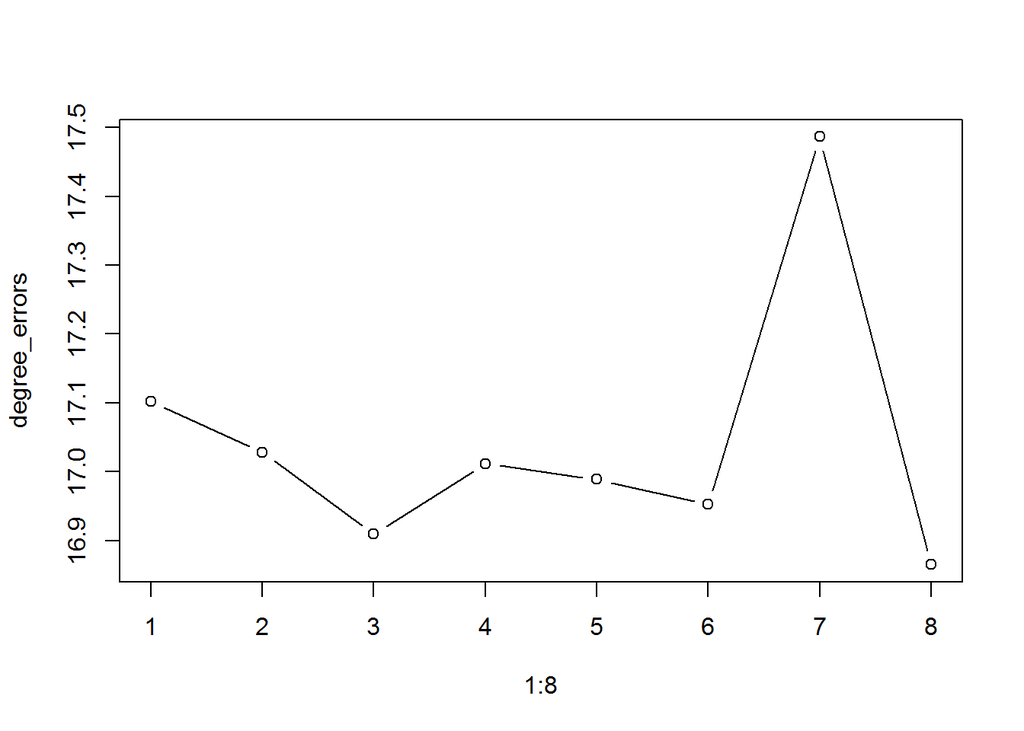

```r
degree_errors = c()
for(degree in 1:8)
{
  glm.fit=glm(mpg~poly(disp+hp+wt+acc,2), data=mpg_df)
  deg_err <- cv.glm(mpg_df, glm.fit, K=5)$delta[1]
  degree_errors[degree] <- deg_err
}

plot(1:8, degree_errors, type='b')
```

(Note: I dont think I saw the “U” until about the 10th Generate…)